# IKEA 沙发与瑞典地名：名字来自最小的那些地方

TidyTuesday · 2026-10-27 (Week 43)

作者

zlZayn

发布于

2026年10月29日

# 名字取自最小的那些地方，价格却与瑞典无关

68.0%  
的地名坐标是农舍或孤屋（121 / 178），是城镇的只有 9 个

2.25×  
最贵与最便宜市场的价格指数差（mx 1.65 对 th 0.73）

2.08×  
同一件商品跨国美元价差的中位数（480 个在十个市场以上销售的编号）

这份数据有趣的地方不在「IKEA 用瑞典地名」这条人尽皆知的事实，而在**这两半几乎不相干**：名字确实来自瑞典，而且来自瑞典最小、最不起眼的那些地点（121 个坐标是只有几户人的农舍或孤屋）；价格却不来自瑞典——同一件商品在五十个市场之间的美元价差中位数 2.08 倍，最贵市场是最便宜市场的 2.25 倍，而名字的故乡瑞典自己正好落在全市场中位上（0.989）。

## 一、口径：一行是什么

`ikea_seating.csv` 的 15,393 行是 2026-09-28 一天的单点快照：50 个市场、每个市场网页上的沙发与扶手椅列表。**一行 = 一个市场 × 一个商品编号**，同一件商品在五十个市场里各占一行，所以行数不是件数。

不同编号只有 2,222 个。其中 696 个只出现在一个市场里，1,494 个不超过五个市场；真正能跨国比价的（十个市场以上）只有 480 个，能覆盖四十五个市场以上的只有 35 个。这条覆盖曲线本身就是第一层结论：**全球同款是个少数派**。

`variants` 是「这件商品还有几个变体」的计数（合计 59,873），不是行数、不是价格、也不是销量。

**两张表怎么对上。** `ikea_places.csv` 的 178 行不是 178 个名字，而是 100 个名字对应的 178 个 OpenStreetMap 地点：33 个名字对到不止一个同名地点，最多的一批各对到五个。

所以不能按 name 把两张表直接 join。那样一张 15,393 行的价目表会变成 22,822 行（×1.48），「某市场卖几件商品」就被悄悄换成了「某市场卖几件商品 × 几个同名地点」。

`AGEN` 是最典型的例子：两个湖、一个 hamlet、一个 bay、一个 neighbourhood，分散在不同郡。

本页的处置是两条互不干扰的路：

1. **价格图完全不 join 地名表**——价格只在 `price_usd` 上算，与地名无关。
2. **地名图用 178 个坐标本身**，因为「一个名字对应多个地点」正是它要说的事。涉及比例的结论同时给出「按坐标」（68.0%）与「按名字」（每个名字取郡县序第一个，66.0%）两套数，两者差 2.0 个百分点，结论不依赖选哪套。

表 1: 本页的口径：两张表各自的粒度、能不能对上、以及为什么不做行级 join

| 项目 | 值 | 说明 |
| --- | --- | --- |
| ikea_seating.csv | 15,393 行 × 12 列 | 一天的单点快照，非均价、非销量 |
| 其中：能对到地名 | 13,660 行（88.7%） | 只有这些行能落到瑞典地图上 |
| 其中：name 为空 | 220 行（IKEA PS 系列等） | 产品名不以瑞典地名命名，不参与地名图 |
| 其中：name 不是瑞典地名 | 1,513 行（9 个名字） | 如 POÄNG、STRANDMON、SMÅSKRAKE、BRÄNNBOLL、GAMMALBYN、BROBOCK、BJÖRKTRAST、SUNDBRON、VENNGARN |
| ikea_places.csv | 178 行 × 8 列 | 坐标数量 > 名字数量 |
| 名字数 | 100 个名字 → 178 个地点，一对多 | 一个名字可以有多个同名地点 |
| 按 name 直接 join 的结果 | 22,822 行（×1.48，不采用） | 行数被地名放大，口径被污染 |
| 可跨国比价的编号 | 480 个（≥10 个市场） | 本页价格部分的全部分母 |
| 覆盖 ≥45 市场的编号 | 35 个 | 本页哑铃图的行数 |

## 二、名字取自瑞典最小的那些地方

> raw 15393 -> plotted 13660 (220 行 name 为空、1,513 行属于 9 个不对应瑞典地名的名字)

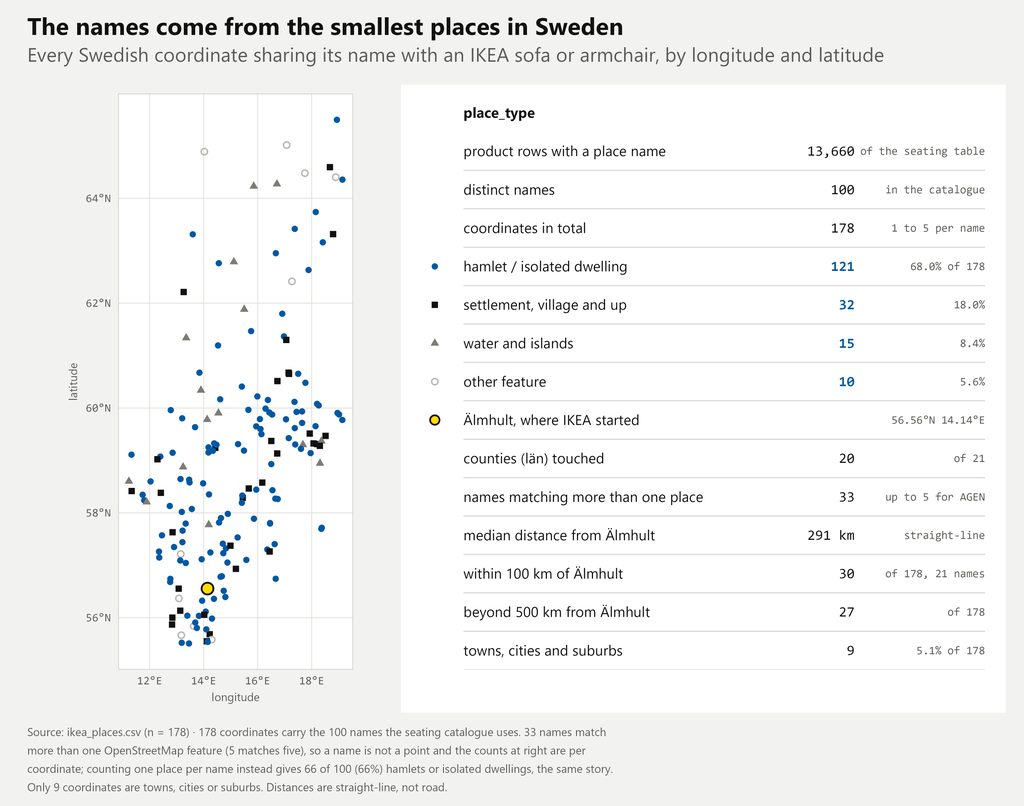

图 1: Two thirds of the coordinates behind IKEA’s sofa names are hamlets or isolated dwellings; the median one is 291 km from Älmhult.

**读数**：178 个坐标里 121 个（68.0%）是 `hamlet` 或 `isolated_dwelling`——OpenStreetMap 里「几户人家」这一级。真正的城镇（town / city / suburb）只有 9 个，占 5.1%。按名字去重是 66 / 100（66.0%），两种算法都指向「约三分之二」。

地理上它并不围着 Småland 转。与 IKEA 老家 Älmhult 的中位直线距离是 291 公里。

50 公里内只有 7 个坐标，100 公里内有 30 个、分属 21 个名字，而 27 个在 500 公里以外。最北是 Norrbottens län 的 HOLMSTA（65.5°N，一个 isolated_dwelling），最南是 Skåne län 的 HAVBERG（55.5°N）。

坐标分布在 20 个郡里（瑞典共 21 个）；22 种 OSM 要素类型中有 14 种只出现一两次。

**这张图不能得出的**：它不是 IKEA 的命名规则清单，只是「被 OpenStreetMap 收进了同名要素」的那些名字——同名要素越多的名字越容易出现在这里，所以点的疏密同时反映命名偏好与瑞典地名的重复度。分布跟着瑞典的人口与地名密度走（南部密集、北部稀疏），不能读成「IKEA 偏爱南部」。

表 2: 图 1 的原始数字（按 178 个坐标计；同名地点可以分属不同类型，所以按坐标比按名字更能体现地图上的墨量）

| grp | 坐标数 | 占比% | 名字数 | 中位距 Älmhult(km) | 50km 内 |
| --- | --- | --- | --- | --- | --- |
| hamlet / isolated dwelling | 121 | 68.0 | 74 | 258 | 7 |
| settlement, village and up | 32 | 18.0 | 31 | 279 | 0 |
| water and islands | 15 | 8.4 | 7 | 373 | 0 |
| other feature | 10 | 5.6 | 8 | 394 | 0 |

## 三、一件商品，价差 1.8 到 4.6 倍

> raw 15393 -> plotted 1663 (13 组 (country, item_no) 重复折叠掉 16 行；2,187 个编号覆盖不到 45 个市场)

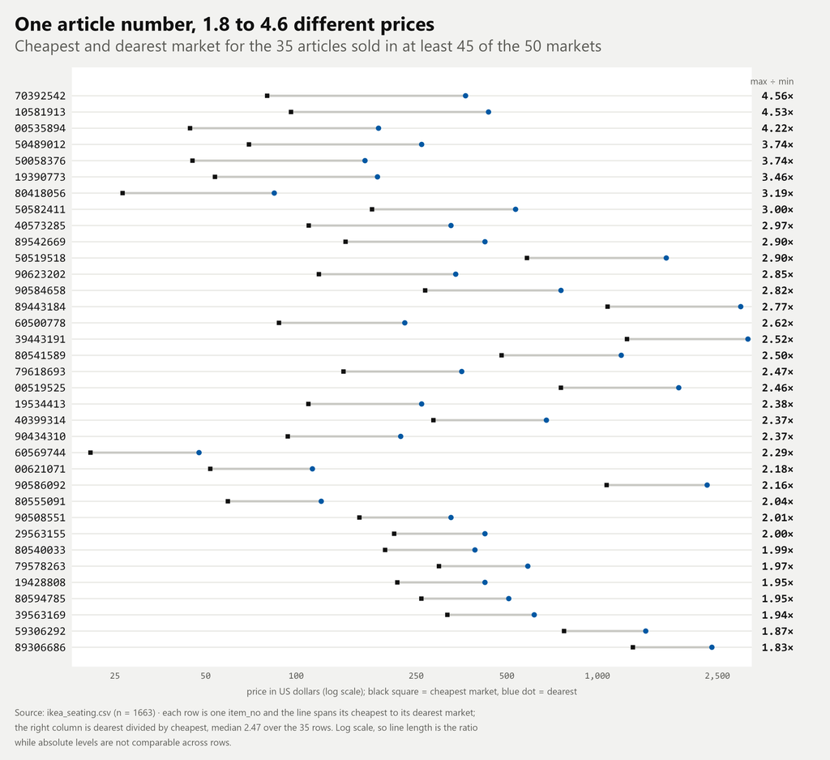

图 2: For the 35 articles sold almost everywhere, the dearest market charges 1.83 to 4.56 times the cheapest.

**读数**：在「几乎全球都在卖」的 35 个编号里，最贵市场与最便宜市场的美元价比中位数是 2.47 倍，区间 1.83 ~ 4.56 倍。

最大的一行是 STRANDMON 70392542：PH 的 80.0 美元对 MA 的 364.7 美元。最小的一行是 VIMLE 89306686，1.83 倍。

两端相当集中：最贵端出现最多的是 IL（12 次），最便宜端是 TH（9 次）；每个编号的两端市场都在下表里。把 480 个可比编号全部算上，中位 2.08 倍、57.9% 的编号差值在两倍以上：**同一个「全球同款」其实是同款不同价**。

**这张图不能得出的**：`price_usd` 只是本地标价乘一个汇率（见下节「数据异常」），不含税制差异、配送、促销、会员价；这是**一天的单点快照**，不是全年均价，也不能读成「某国更贵」的长期结论。图只画了覆盖最广的 35 个编号，它们恰好是最标准化、最可能被统一定价的那些。

表 3: 图 2 的原始数字（按倍数降序；价格单位为 2026-09-28 的美元，n = 35 个编号 × 1663 个市场行）

| 编号 | 产品名 | 市场数 | 最低 $ | 最低市场 | 最高 $ | 最高市场 | 中位 $ | 倍数 |
| --- | --- | --- | --- | --- | --- | --- | --- | --- |
| 70392542 | STRANDMON | 48 | 80.04 | PH | 364.71 | MA | 154.09 | 4.56 |
| 10581913 | SOTENÄS | 48 | 96.05 | PH | 434.68 | EG | 260.81 | 4.53 |
| 00535894 | ÅRSUNDA | 48 | 44.39 | TH | 187.51 | MA | 61.28 | 4.22 |
| 50489012 | GLOSTAD | 50 | 69.65 | SG | 260.70 | IL | 143.78 | 3.74 |
| 50058376 | AGEN | 49 | 45.23 | CA | 169.10 | MX | 69.58 | 3.74 |
| 19390773 | AGEN | 49 | 53.71 | CA | 186.02 | MX | 79.71 | 3.46 |
| 80418056 | POÄNG | 50 | 26.51 | KR | 84.52 | MX | 36.39 | 3.19 |
| 50582411 | TORNSBORG | 46 | 178.43 | TH | 534.56 | JO | 324.57 | 3.00 |
| 40573285 | GLOSTAD | 48 | 110.00 | MY | 326.28 | IL | 177.14 | 2.97 |
| 89542669 | GLOSTAD | 46 | 145.75 | JP | 423.02 | IL | 229.62 | 2.90 |
| 50519518 | KIVIK | 47 | 583.15 | RO | 1691.53 | MX | 966.93 | 2.90 |
| 90623202 | — | 48 | 118.86 | TH | 338.26 | MX | 153.82 | 2.85 |
| 90584658 | TORNSBORG | 45 | 267.80 | TH | 756.45 | CO | 454.42 | 2.82 |
| 89443184 | KIVIK | 47 | 1079.91 | RO | 2988.36 | MX | 1662.18 | 2.77 |
| 60500778 | SALNÖ | 46 | 87.62 | KR | 229.21 | MA | 138.61 | 2.62 |
| 39443191 | KIVIK | 49 | 1252.70 | RO | 3157.52 | MX | 1786.86 | 2.52 |
| 80541589 | BÅRSLÖV | 48 | 480.34 | PH | 1199.00 | US | 691.29 | 2.50 |
| 79618693 | POÄNG | 46 | 143.44 | KR | 354.18 | MA | 168.90 | 2.47 |
| 00519525 | KIVIK | 47 | 755.94 | RO | 1860.69 | MX | 1123.78 | 2.46 |
| 19534413 | SALNÖ | 46 | 109.71 | KR | 260.70 | IL | 169.70 | 2.38 |
| 40399314 | KLIPPAN | 49 | 285.22 | JP | 676.58 | MX | 412.74 | 2.37 |
| 90434310 | ULRIKSBERG | 50 | 93.70 | IN | 222.12 | EG | 139.97 | 2.37 |
| 60569744 | SMÅSKRAKE | 47 | 20.74 | IN | 47.55 | IL | 28.36 | 2.29 |
| 00621071 | — | 49 | 51.82 | PL | 113.13 | IL | 68.32 | 2.18 |
| 90586092 | STOCKHOLM | 49 | 1072.10 | TH | 2311.78 | MX | 1593.33 | 2.16 |
| 80555091 | MOFALLA | 50 | 59.28 | TH | 121.03 | CO | 86.71 | 2.04 |
| 90508551 | HOLMSTA | 46 | 162.01 | AE | 326.28 | IL | 226.64 | 2.01 |
| 29563155 | FRYKSÅS | 46 | 211.32 | CA | 423.02 | IL | 296.52 | 2.00 |
| 80540033 | FRYKSÅS | 46 | 197.18 | CA | 391.87 | IL | 275.92 | 1.99 |
| 79578263 | STOCKHOLM | 47 | 297.59 | TH | 586.98 | IL | 397.48 | 1.97 |
| 19428808 | HOLMSTA | 46 | 216.47 | AE | 423.02 | IL | 283.59 | 1.95 |
| 80594785 | STOCKHOLM | 50 | 260.16 | PL | 507.42 | MX | 340.53 | 1.95 |
| 39563169 | FRYKSÅS | 45 | 317.33 | CA | 616.49 | IL | 439.00 | 1.94 |
| 59306292 | VIMLE | 46 | 774.21 | TH | 1445.67 | CH | 1001.09 | 1.87 |
| 89306686 | VIMLE | 46 | 1310.41 | TH | 2397.25 | MA | 1756.72 | 1.83 |

## 四、谁贵谁便宜：五十个市场的价格指数

> raw 15393 -> plotted 10493 (沿用上一步的折叠；1,742 个编号覆盖不到 10 个市场，无法构造可比价)

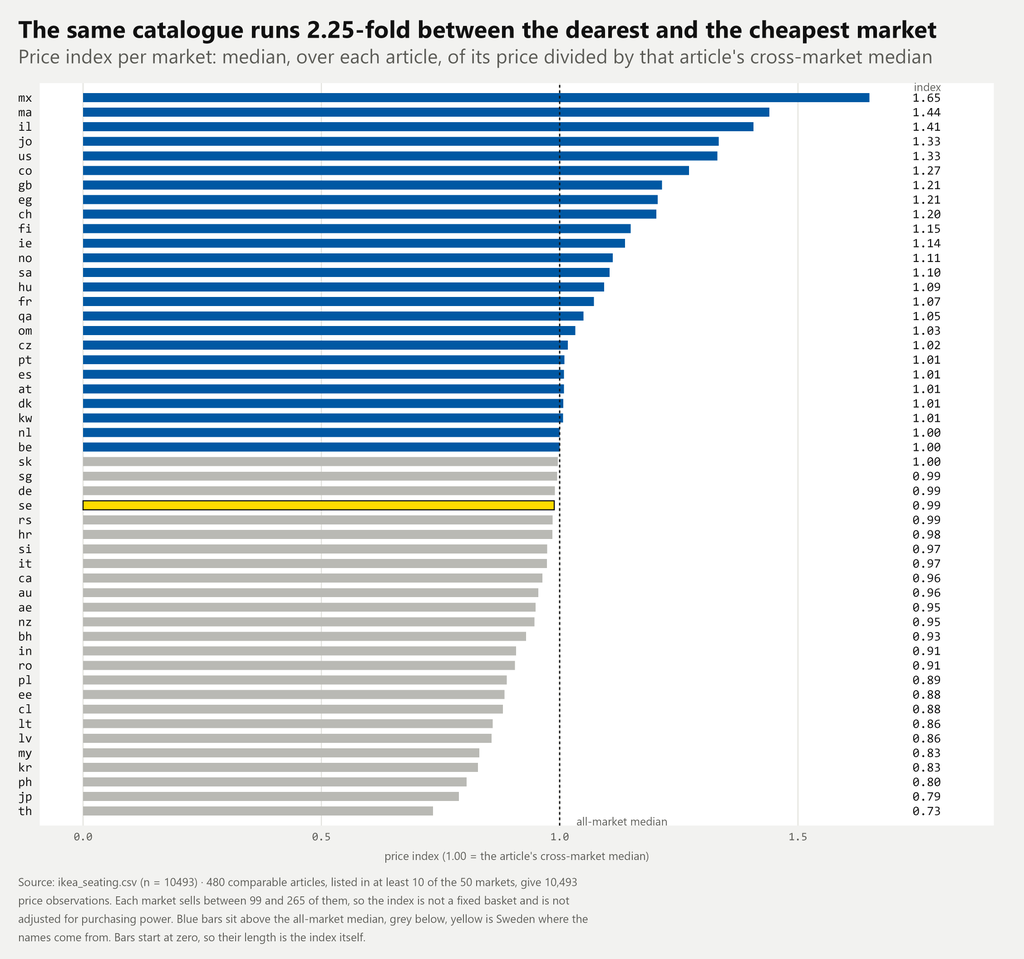

图 3: Mexico pays 1.65 times the cross-market median and Thailand 0.73; Sweden, where the names come from, sits at 0.99.

货币本身也解释不了它：16 个市场用同一种欧元，指数仍从 0.86（LV）排到 1.15（FI）；同一个编号 00621071 在这 16 个欧元市场里的本地标价从 49.99 到 79.99 欧——**同币不同价**。

**这张图不能得出的**：它不是物价水平排名，是「同一份目录在各市场的相对位置」。每个市场能比的商品数从 99 到 265 不等，MX 只有 99 个可比商品，它的 1.65 建立在一个窄得多的样本上。指数也没做购买力平价调整，价格来自网页标价，税前税后、促销与否都可能不同。

表 4: 图 3 的原始数字（50 个市场按指数降序；1.000 = 该市场的可比商品相对各自跨国中位的中位比值）

| 市场 | 价格指数 | 可比商品数 | 名义方向 |
| --- | --- | --- | --- |
| MX | 1.650 | 99 | 高于中位 |
| MA | 1.440 | 204 | 高于中位 |
| IL | 1.407 | 240 | 高于中位 |
| JO | 1.334 | 221 | 高于中位 |
| US | 1.331 | 143 | 高于中位 |
| CO | 1.272 | 125 | 高于中位 |
| GB | 1.215 | 195 | 高于中位 |
| EG | 1.206 | 231 | 高于中位 |
| CH | 1.203 | 212 | 高于中位 |
| FI | 1.149 | 227 | 高于中位 |
| IE | 1.137 | 164 | 高于中位 |
| NO | 1.112 | 232 | 高于中位 |
| SA | 1.105 | 138 | 高于中位 |
| HU | 1.093 | 238 | 高于中位 |
| FR | 1.072 | 249 | 高于中位 |
| QA | 1.050 | 224 | 高于中位 |
| OM | 1.033 | 211 | 高于中位 |
| CZ | 1.017 | 206 | 高于中位 |
| PT | 1.010 | 229 | 高于中位 |
| ES | 1.009 | 238 | 高于中位 |
| AT | 1.009 | 251 | 高于中位 |
| DK | 1.007 | 233 | 高于中位 |
| KW | 1.007 | 210 | 高于中位 |
| BE | 1.000 | 265 | 高于中位 |
| NL | 1.000 | 236 | 高于中位 |
| SK | 0.996 | 226 | 低于中位 |
| SG | 0.995 | 175 | 低于中位 |
| DE | 0.990 | 237 | 低于中位 |
| SE | 0.989 | 256 | 低于中位 |
| RS | 0.985 | 248 | 低于中位 |
| HR | 0.985 | 236 | 低于中位 |
| SI | 0.974 | 256 | 低于中位 |
| IT | 0.973 | 250 | 低于中位 |
| CA | 0.964 | 132 | 低于中位 |
| AU | 0.955 | 214 | 低于中位 |
| AE | 0.950 | 220 | 低于中位 |
| NZ | 0.947 | 199 | 低于中位 |
| BH | 0.930 | 225 | 低于中位 |
| IN | 0.908 | 122 | 低于中位 |
| RO | 0.906 | 257 | 低于中位 |
| PL | 0.889 | 232 | 低于中位 |
| EE | 0.884 | 225 | 低于中位 |
| CL | 0.881 | 155 | 低于中位 |
| LT | 0.860 | 212 | 低于中位 |
| LV | 0.857 | 224 | 低于中位 |
| MY | 0.831 | 195 | 低于中位 |
| KR | 0.829 | 187 | 低于中位 |
| PH | 0.805 | 186 | 低于中位 |
| JP | 0.788 | 213 | 低于中位 |
| TH | 0.734 | 190 | 低于中位 |

## 数据异常（记录，不改数据）

[output not shown]

## 方法与口径

| 项 | 值 |
| --- | --- |
| 数据 | `data/ikea_seating.csv`（15,393 × 12，50 个市场，2026-09-28 单日快照）；`data/ikea_places.csv`（178 × 8，来自 OpenStreetMap / Nominatim，ODbL） |
| 覆盖 | 市场 50 个（无 `tw`）、货币 35 种、商品编号 2,222 个；地名 100 个名字 / 178 个坐标 / 20 个郡 |
| 入图样本 | 图 1：178 个坐标；图 2：raw 15393 -> plotted 1663 (13 组 (country, item_no) 重复折叠掉 16 行；2,187 个编号覆盖不到 45 个市场)；图 3：raw 15393 -> plotted 10493 (沿用上一步的折叠；1,742 个编号覆盖不到 10 个市场，无法构造可比价) |
| 图 1 口径 | 用 `longitude` / `latitude` 直接画矩形坐标（不加载 sf、不画底图）；`coord_fixed` 按平均纬度做经度压缩；四组按 `place_type` 归并；Älmhult 坐标 56.5556°N 14.1433°E 为参考点，距离为平面近似（等距圆柱），非路网距离 |
| 图 2 口径 | 只取 35 个 ≥45 个市场的编号；每个编号取 `min(price_usd)` 与 `max(price_usd)` 两端，对数横轴使线长 = 倍数；不画中位标记（倍数已在右列给出）；1663 个「编号 × 市场」观测 |
| 图 3 口径 | 480 个 ≥10 个市场的编号；每个市场在「该市场卖得动的这些编号」内算 `price_usd ÷ 该编号的跨国中位`，再取中位；横条从 0 起，不做截断；指数 1.000 = 该编号的中位水平 |
| 不作为证据的列 | `product_type`（按国家本地化的自由文本）、`language`（同上）、`url`（纯标识）、`variants`（「还有几个变体」的计数，与价格、销量都无关）、`price`（本地货币，跨国不可比，只用来验证 `price_usd` 是换算） |
| 数字来源 | 正文所有数字来自本页 prep chunk 的同一份聚合；内联数字一律经 `sprintf` / `format` 定型，避开 knitr 对大数的科学计数法改写 |
| 不画的东西 | 不画 sf 投影地图（2026-09-01 已用，且只有 178 个点不需要底图）；不画 100% 堆叠柱（2026-09-29 已用）；不画屋脊（2026-09-29 已用）；不按 `category` 比价（类目本身有归类错误）；不画汇率或时间序列（只有一天）；不做国家层面的人均或 PPP 调整（数据里没有收入与人口） |